Retained ancillary notebook excerpts

# Mental Health

Inter-evaluator reliability, probability ECE, and severity–entropy correlations, with their original code and saved outputs.

These excerpts come from `02_univariate_mh.ipynb`. All selected cells and their saved outputs are shown; original cell indexes are retained. The earlier G-study results are outside this excerpt. Packaging did not execute the analysis.

**Metric interpretation:** ECE uses each evaluator’s own modal label after item × evaluator aggregation, with mean probability vectors. It is not calibration against independently verified human labels. The entropy correlation uses mean severity as the retained notebook’s descriptive θ proxy; the baseline condition averages the three seeds at gpt-4o-mini / rubric / temperature 0.

The archived alpha helper uses squared distance between ranks of the observed categories. Its exact implementation is included below; the notebook’s “ordinal alpha” label is preserved without new methodological validation.

**Mental Health provenance:** `original_label` comes from `u_label` in the retained sampling workflow; correspondence to source-corpus `status` remains unresolved. The ancillary ECE shown here uses evaluator modal labels, not that external reference column.

**Source hashes, coverage and publication notes**

Frozen notebook SHA-256: `462457bbcee85b0fba76f81eb41058bff5eb986d6788505fea124a177d498093`.

Original selected cell indexes (zero-based): `1, 2, 3, 16, 17, 18, 19, 20, 26`. Coverage: 7 code cells, 10 saved output records, 1 embedded figures. Saved Python version: 3.11.0.

The private project-root prefix is replaced by `.` in the publication copy. Colab scripts and controls are inert in the rendered output; their complete HTML is retained as escaped text. Account identifiers and notebook UI metadata are omitted. Numerical outputs are not altered.

The helper definitions were recovered from the frozen legacy Colab backup of `gtheory_analysis_utils.py` (two byte-identical retained copies). Its SHA-256 is `c24da135808f28e89d5a532d102b4458f611926d244348312632ce379c74e8e7`. The notebook records the import name but no hash of the helper loaded at execution time, so the exact runtime/helper association cannot be established from the retained metadata.

Packaged on 2026-09-10. Only source packaging, sanitation and content checks were performed; no annotation, model fitting or metric recomputation was performed.

| Cell | Execution count | Saved status | Saved timestamp (UTC) | Saved elapsed value |
| --- | --- | --- | --- | --- |
| 1 | 1 | ok | 2026-04-20T04:43:43.635Z | 19828 |
| 2 | 2 | ok | 2026-04-20T04:43:46.385Z | 2747 |
| 3 | 3 | ok | 2026-04-20T04:43:46.539Z | 139 |
| 17 | 13 | ok | 2026-04-20T05:23:38.466Z | 3556 |
| 19 | 14 | ok | 2026-04-20T05:23:38.890Z | 423 |
| 20 | 15 | ok | 2026-04-20T05:23:39.174Z | 280 |
| 26 | 20 | ok | 2026-04-20T05:23:40.051Z | 111 |

## Local use of the excerpts

Run in a Python notebook from the downloaded repository root, with annotation CSVs from [OSF](https://osf.io/k9caj/) under `data/`. The matching sample CSVs listed in reproduction instructions are also required; they are not included in this GitHub package or verified as present in the OSF deposit, so a complete rerun depends on obtaining them. Use the local setup below and the three helper definitions, then run the included original code cells in ascending order **starting at cell 2**. Historical cell 1 is retained for provenance; the local setup replaces its Colab paths and broad helper imports.

**Local setup for this excerpt (publication adaptation, not a saved analysis cell)**

```
from pathlib import Path
import numpy as np
import pandas as pd
import matplotlib.pyplot as plt
import seaborn as sns
from IPython.display import display

DATA_DIR = Path("data").resolve()
OUTPUTS_DIR = Path("outputs/ancillary_mental_health").resolve()
OUTPUTS_DIR.mkdir(parents=True, exist_ok=True)
sns.set_style("whitegrid")
plt.rcParams["figure.figsize"] = (12, 6)
plt.rcParams["figure.dpi"] = 120
plt.rcParams["font.size"] = 11
```

Dependencies: Python, NumPy, pandas, SciPy, scikit-learn, matplotlib, seaborn and IPython. The historical setup also imports statsmodels. A complete locked Python environment is not retained.

## Archived helper definitions

Exact function bodies from the retained helper; NumPy and pandas imports are supplied by the local setup above. The pairwise helper imports scikit-learn internally. No helper output is newly computed here.

**krippendorff_alpha_ordinal (source lines 1266–1317)**

```
def krippendorff_alpha_ordinal(ratings_matrix):
    """
    Compute Krippendorff's alpha for ordinal data.
    ratings_matrix: DataFrame with items as rows, raters as columns.
    Uses squared ordinal distance metric.
    """
    values = sorted(ratings_matrix.stack().unique())
    val_map = {v: i for i, v in enumerate(values)}

    unit_counts = []
    for _, row in ratings_matrix.iterrows():
        vals = row.dropna().values
        if len(vals) < 2:
            continue
        counts = {}
        for v in vals:
            counts[v] = counts.get(v, 0) + 1
        unit_counts.append((len(vals), counts))

    if not unit_counts:
        return np.nan

    total_disagreement = 0
    total_pairs = 0
    marginals = {}

    for m_u, counts in unit_counts:
        for c, n_c in counts.items():
            marginals[c] = marginals.get(c, 0) + n_c
            for k, n_k in counts.items():
                if c != k:
                    dist = (val_map[c] - val_map[k]) ** 2
                    total_disagreement += n_c * n_k * dist
            total_pairs += n_c * (m_u - 1)

    if total_pairs == 0:
        return np.nan

    Do = total_disagreement / total_pairs

    n_total = sum(marginals.values())
    De = 0
    for c in marginals:
        for k in marginals:
            if c != k:
                dist = (val_map[c] - val_map[k]) ** 2
                De += marginals[c] * marginals[k] * dist
    De /= (n_total * (n_total - 1))

    if De == 0:
        return 1.0
    return 1 - Do / De
```

Excerpt SHA-256: `63e044d39398f1fca7da1ca63ec9393b3e9f662e710d5469ab6606921f299828`

**pairwise_agreement (source lines 1320–1367)**

```
def pairwise_agreement(df, item_col, rater_col, label_col,
                       agg_func='mode', metric='accuracy'):
    """
    Compute pairwise inter-rater agreement matrix.

    Parameters
    ----------
    df : DataFrame
    item_col, rater_col, label_col : str
    agg_func : 'mode' or 'mean' — how to aggregate across seeds/temps
    metric : 'accuracy' or 'kappa'

    Returns
    -------
    pd.DataFrame — symmetric matrix of pairwise agreement
    """
    import pandas as pd
    from sklearn.metrics import cohen_kappa_score

    if agg_func == 'mode':
        agg = df.groupby([item_col, rater_col])[label_col].agg(
            lambda x: x.mode().iloc[0] if len(x.mode()) > 0 else x.iloc[0]
        ).reset_index()
    else:
        agg = df.groupby([item_col, rater_col])[label_col].mean().reset_index()

    pivot = agg.pivot(index=item_col, columns=rater_col, values=label_col)
    raters = sorted(pivot.columns)

    mat = pd.DataFrame(np.nan, index=raters, columns=raters)
    for i, r1 in enumerate(raters):
        mat.loc[r1, r1] = 1.0
        for r2 in raters[i + 1:]:
            valid = pivot[[r1, r2]].dropna()
            if len(valid) == 0:
                continue
            if metric == 'kappa':
                try:
                    k = cohen_kappa_score(valid[r1], valid[r2], weights='quadratic')
                except:
                    k = np.nan
                mat.loc[r1, r2] = round(k, 4)
                mat.loc[r2, r1] = round(k, 4)
            else:
                acc = (valid[r1] == valid[r2]).mean()
                mat.loc[r1, r2] = round(acc, 4)
                mat.loc[r2, r1] = round(acc, 4)
    return mat
```

Excerpt SHA-256: `3fcc8793379dc6b6d93ecb23d7933ba60dd786128e5ea054e177a531013e6648`

**calibration_metrics (source lines 1370–1420)**

```
def calibration_metrics(df, prob_cols, label_col, labels, n_bins=10):
    """
    Compute Expected Calibration Error (ECE) and per-class calibration data.

    Returns dict with 'ece' and 'per_class' calibration curves.
    """
    results = {'ece': 0, 'per_class': {}}
    total_samples = len(df)

    for label, prob_col in zip(labels, prob_cols):
        is_positive = (df[label_col] == label).astype(float).values
        probs = df[prob_col].values.astype(float)

        # Bin probabilities
        bin_edges = np.linspace(0, 1, n_bins + 1)
        bin_centers = []
        bin_accs = []
        bin_confs = []
        bin_counts = []

        for b in range(n_bins):
            mask = (probs >= bin_edges[b]) & (probs < bin_edges[b + 1])
            if b == n_bins - 1:
                mask = (probs >= bin_edges[b]) & (probs <= bin_edges[b + 1])
            if mask.sum() == 0:
                continue
            bin_acc = is_positive[mask].mean()
            bin_conf = probs[mask].mean()
            bin_centers.append((bin_edges[b] + bin_edges[b + 1]) / 2)
            bin_accs.append(bin_acc)
            bin_confs.append(bin_conf)
            bin_counts.append(mask.sum())

        results['per_class'][label] = {
            'bin_centers': bin_centers,
            'bin_accs': bin_accs,
            'bin_confs': bin_confs,
            'bin_counts': bin_counts,
        }

    # Overall ECE: weighted average |acc - conf| across all bins and classes
    total_ece = 0
    total_n = 0
    for label_data in results['per_class'].values():
        for acc, conf, cnt in zip(label_data['bin_accs'], label_data['bin_confs'],
                                   label_data['bin_counts']):
            total_ece += cnt * abs(acc - conf)
            total_n += cnt
    results['ece'] = total_ece / max(total_n, 1)

    return results
```

Excerpt SHA-256: `71c249866113405776813550c737b7e27f1032e23c2ddf98fcc2cbd0d2b3f002`

Original cell 1 · code · saved execution 1

```
import sys, os, warnings
import numpy as np
import pandas as pd
import matplotlib.pyplot as plt
import seaborn as sns
from pathlib import Path
from scipy import stats
from sklearn.metrics import (
    cohen_kappa_score, classification_report,
    accuracy_score, f1_score,
)
from statsmodels.miscmodels.ordinal_model import OrderedModel

# -- Paths (Google Drive on Colab) --
from google.colab import drive
drive.mount('/content/drive')

BASE_DIR = Path("./02.MentalHealth")
DATA_DIR = BASE_DIR / "data"
OUTPUTS_DIR = BASE_DIR / "outputs"
OUTPUTS_DIR.mkdir(parents=True, exist_ok=True)
os.chdir(BASE_DIR)

# Import shared utility module (lives in project root)
UTILS_DIR = Path(".")
sys.path.insert(0, str(UTILS_DIR))
from gtheory_analysis_utils import (
    variance_components_crossed,
    g_coefficient,
    dependability_coefficient,
    d_study_grid,
    krippendorff_alpha_ordinal,
    pairwise_agreement,
    calibration_metrics,
    accuracy_vs_ground_truth,
    compute_observation_entropy,
    max_entropy,
)

warnings.filterwarnings("ignore")
pd.set_option("display.max_columns", 40)
pd.set_option("display.width", 140)
sns.set_style("whitegrid")

print("Setup complete.")
print(f"BASE_DIR: {BASE_DIR}")
print(f"OUTPUTS_DIR: {OUTPUTS_DIR}")
```

Saved output 1 · stream

```
Setup complete.
BASE_DIR: ./02.MentalHealth
OUTPUTS_DIR: ./02.MentalHealth/outputs
```

Original cell 2 · code · saved execution 2

```
# Load main labeling results
results = pd.read_csv("data/mh_labeling_final.csv")
print(f"Loaded {len(results):,} rows, {results.shape[1]} columns")
print(f"Columns: {list(results.columns)}")

# Validate completeness
n_items = results["item_id"].nunique()
n_evals = results["evaluator"].nunique()
n_prompts = results["prompt_type"].nunique()
n_temps = results["temperature"].nunique()
n_seeds = results["seed"].nunique()
expected = n_items * n_evals * n_prompts * n_temps * n_seeds
print(f"\nDesign: {n_items} items × {n_evals} evaluators × {n_prompts} prompts "
      f"× {n_temps} temps × {n_seeds} seeds = {expected:,}")
assert len(results) == expected == 21600, f"Expected 21,600 rows, got {len(results):,}"
print("Completeness check PASSED: 21,600 rows ✓")

# Load sample metadata
sample = pd.read_csv("data/mh_sample_100.csv")
sample['entropy_stratum'] = sample['entropy_stratum'].replace({'Q1': 'Q1 & Q2', 'Q2': 'Q1 & Q2'})
print(f"\nSample metadata: {len(sample)} items")
print(f"  Strata: {sample['entropy_stratum'].value_counts().to_dict()}")
print(f"  Labels: {sample['original_label'].value_counts().to_dict()}")

# Merge entropy_stratum and original_label into results
results = results.merge(
    sample[["item_id", "entropy_stratum", "original_label"]],
    on="item_id",
    how="left",
)
print(f"\nAfter merge: {len(results):,} rows (should still be 21,600)")
assert len(results) == 21600
print("Merge check PASSED ✓")
```

Saved output 1 · stream

```
Loaded 21,600 rows, 27 columns
Columns: ['call_id', 'item_id', 'custom_id', 'evaluator', 'prompt_type', 'temperature', 'seed', 'label', 'prob_normal', 'prob_depression', 'prob_anxiety', 'prob_suicidal', 'prob_stress', 'prob_bipolar', 'prob_personality_disorder', 'depression_present', 'anxiety_present', 'suicidal_present', 'stress…

Design: 100 items × 4 evaluators × 3 prompts × 6 temps × 3 seeds = 21,600
Completeness check PASSED: 21,600 rows ✓

Sample metadata: 100 items
  Strata: {'Q1 & Q2': 52, 'Q3': 29, 'Q4': 19}
  Labels: {'NORMAL': 29, 'SUICIDAL': 24, 'DEPRESSION': 21, 'ANXIETY': 17, 'BIPOLAR': 4, 'STRESS': 3, 'PERSONALITY_DISORDER': 2}

After merge: 21,600 rows (should still be 21,600)
Merge check PASSED ✓
```

Original cell 3 · code · saved execution 3

```
# Mapping A: 7-level severity (ordinal assumption for G-theory)
severity_7_map = {
    "NORMAL": 1,
    "STRESS": 2,
    "ANXIETY": 3,
    "DEPRESSION": 4,
    "BIPOLAR": 5,
    "PERSONALITY_DISORDER": 6,
    "SUICIDAL": 7,
}
results["severity_7"] = results["label"].map(severity_7_map)

# Mapping B: Collapsed 3-level (sensitivity analysis)
# Groups sparse categories (BIPOLAR n=4, PD n=2) with adjacent severe
# conditions while preserving the ordinal severity gradient:
#   normal = 1: NORMAL, STRESS
#   mild   = 2: ANXIETY, DEPRESSION
#   severe = 3: BIPOLAR, PERSONALITY_DISORDER, SUICIDAL
severity_3_map = {
    "NORMAL": 1,
    "STRESS": 1,
    "ANXIETY": 2,
    "DEPRESSION": 2,
    "BIPOLAR": 3,
    "PERSONALITY_DISORDER": 3,
    "SUICIDAL": 3,
}
results["severity_3"] = results["label"].map(severity_3_map)

print("=== Severity 7-level distribution ===")
print(results["severity_7"].value_counts().sort_index())
print(f"\nMean: {results['severity_7'].mean():.3f}, SD: {results['severity_7'].std():.3f}")

print("\n=== Severity 3-level distribution ===")
print(results["severity_3"].value_counts().sort_index())
print(f"\nMean: {results['severity_3'].mean():.3f}, SD: {results['severity_3'].std():.3f}")

# Verify no NaN
assert results["severity_7"].notna().all(), "NaN in severity_7!"
assert results["severity_3"].notna().all(), "NaN in severity_3!"
print("\nNo missing severity values ✓")
```

Saved output 1 · stream

```
=== Severity 7-level distribution ===
severity_7
1    7898
2    1260
3    3064
4    4467
5     673
6     197
7    4041
Name: count, dtype: int64

Mean: 3.255, SD: 2.205

=== Severity 3-level distribution ===
severity_3
1    9158
2    7531
3    4911
Name: count, dtype: int64

Mean: 1.803, SD: 0.783

No missing severity values ✓
```

Original cell 16 · markdown

## Per-Item Difficulty (θ Proxy) & Entropy–θ Correlations

The mean severity per item, averaged over all 216 observations (4 evaluators × 3 prompts × 6 temps × 3 seeds), serves as a sufficient statistic for the Rasch item difficulty parameter θ.

Three entropy–θ correlations test whether model-generated uncertainty predicts item difficulty:

1. **Baseline entropy ↔︎ mean severity** — baseline = gpt-4o-mini × rubric × temp=0 (gpt-4o-mini screening condition)
2. **All-condition entropy ↔︎ mean severity** — entropy averaged over all 216 observations
3. **Baseline entropy ↔︎ all-condition entropy** — validates single-call entropy as a proxy for multi-evaluator entropy

**Original Markdown text**

```
## Per-Item Difficulty (θ Proxy) & Entropy–θ Correlations

The mean severity per item, averaged over all 216 observations (4 evaluators × 3 prompts × 6 temps × 3 seeds), serves as a sufficient statistic for the Rasch item difficulty parameter θ.

Three entropy–θ correlations test whether model-generated uncertainty predicts item difficulty:
1. **Baseline entropy ↔ mean severity** — baseline = gpt-4o-mini × rubric × temp=0 (gpt-4o-mini screening condition)
2. **All-condition entropy ↔ mean severity** — entropy averaged over all 216 observations
3. **Baseline entropy ↔ all-condition entropy** — validates single-call entropy as a proxy for multi-evaluator entropy
```

Original cell 17 · code · saved execution 13

```
# ── Per-Item Difficulty (θ proxy) & Entropy–θ Correlations ──
from scipy.stats import spearmanr, pearsonr

# Probability columns for Shannon entropy (7-class)
_prob_cols = ['prob_normal', 'prob_depression', 'prob_anxiety', 'prob_suicidal',
              'prob_stress', 'prob_bipolar', 'prob_personality_disorder']

def _shannon_h(row, cols):
    probs = [row[c] for c in cols if pd.notna(row[c]) and row[c] > 0]
    return -sum(p * np.log2(p) for p in probs) if probs else 0.0

# 1. Per-item mean severity (θ proxy): averaged over all 216 observations
item_theta = results.groupby('item_id')['severity_7'].mean().reset_index()
item_theta.columns = ['item_id', 'mean_severity']

# 2. Baseline entropy: gpt-4o-mini × rubric × temp=0 (gpt-4o-mini screening condition)
ref_single = results[
    (results['evaluator'] == 'gpt-4o-mini') &
    (results['prompt_type'] == 'rubric') &
    (results['temperature'].astype(float) == 0.0)
].copy()
ref_single['_h'] = ref_single.apply(lambda r: _shannon_h(r, _prob_cols), axis=1)
baseline_h = ref_single.groupby('item_id')['_h'].mean().reset_index()
baseline_h.columns = ['item_id', 'baseline_entropy']

# 3. All-condition entropy: averaged over all 216 observations per item
results['_h_all'] = results.apply(lambda r: _shannon_h(r, _prob_cols), axis=1)
allcond_h = results.groupby('item_id')['_h_all'].mean().reset_index()
allcond_h.columns = ['item_id', 'allcond_entropy']

# Merge into item-level DataFrame
item_df = item_theta.merge(baseline_h, on='item_id').merge(allcond_h, on='item_id')
_samp = sample[['item_id', 'entropy_stratum']].copy()
_samp['item_id'] = _samp['item_id'].astype(str)
item_df['item_id'] = item_df['item_id'].astype(str)
item_df = item_df.merge(_samp, on='item_id', how='left')

print(f"Items: {len(item_df)}")
print(f"\n{'='*70}")
print("Per-Item θ Proxy (Mean Severity) & Entropy Summary")
print(f"{'='*70}")
print(item_df[['mean_severity', 'baseline_entropy', 'allcond_entropy']].describe().round(3).to_string())

# ── Three Correlations (Spearman + Pearson) ──
print(f"\n{'='*70}")
print("Entropy–θ Correlations")
print(f"{'='*70}")
corr_specs = [
    ('Baseline Entropy ↔ Mean Severity', 'baseline_entropy', 'mean_severity'),
    ('All-Condition Entropy ↔ Mean Severity', 'allcond_entropy', 'mean_severity'),
    ('Baseline Entropy ↔ All-Condition Entropy', 'baseline_entropy', 'allcond_entropy'),
]
corr_rows = []
for label, c1, c2 in corr_specs:
    rho, p_rho = spearmanr(item_df[c1], item_df[c2])
    r, p_r = pearsonr(item_df[c1], item_df[c2])
    corr_rows.append({'Comparison': label,
                      'Spearman ρ': round(rho, 3), 'p (Spearman)': f'{p_rho:.2e}',
                      'Pearson r': round(r, 3), 'p (Pearson)': f'{p_r:.2e}'})
    print(f"  {label}:")
    print(f"    Spearman ρ = {rho:.3f} (p = {p_rho:.2e})")
    print(f"    Pearson  r = {r:.3f} (p = {p_r:.2e})")
corr_table_theta = pd.DataFrame(corr_rows)
display(corr_table_theta)

# ── Scatter: Baseline Entropy (X) vs Mean Severity (Y) ──
fig, ax = plt.subplots(figsize=(8, 6))
colors_q = {'Q1 & Q2': 'green', 'Q3': 'orange', 'Q4': 'red'}
for s in ['Q1 & Q2', 'Q3', 'Q4']:
    sub = item_df[item_df['entropy_stratum'] == s]
    if len(sub) > 0:
        ax.scatter(sub['baseline_entropy'], sub['mean_severity'],
                   c=colors_q[s], label=s, alpha=0.7, s=60, edgecolors='white')
z = np.polyfit(item_df['baseline_entropy'], item_df['mean_severity'], 1)
x_line = np.linspace(item_df['baseline_entropy'].min(), item_df['baseline_entropy'].max(), 100)
ax.plot(x_line, np.polyval(z, x_line), 'k--', alpha=0.5)
rho, p = spearmanr(item_df['baseline_entropy'], item_df['mean_severity'])
ax.set_xlabel('Baseline Entropy (gpt-4o-mini / rubric / temp=0)')
ax.set_ylabel('Mean Severity (θ proxy, averaged over 216 obs)')
ax.set_title(f'Item Difficulty vs Baseline Entropy (ρ={rho:.3f}, p={p:.2e})')
ax.legend(title='Entropy Stratum')
plt.tight_layout()
plt.savefig(OUTPUTS_DIR / f'mh_theta_entropy_scatter.png', dpi=150, bbox_inches='tight')
plt.show()

# Clean up temp columns
results.drop(columns=['_h_all'], inplace=True, errors='ignore')

corr_table_theta.to_csv(OUTPUTS_DIR / f'mh_entropy_theta_correlations.csv', index=False)
item_df.to_csv(OUTPUTS_DIR / f'mh_item_theta_proxy.csv', index=False)
print(f"\nSaved to {OUTPUTS_DIR}")
```

Saved output 1 · stream

```
Items: 100

======================================================================
Per-Item θ Proxy (Mean Severity) & Entropy Summary
======================================================================
       mean_severity  baseline_entropy  allcond_entropy
count        100.000           100.000          100.000
mean           3.255             0.412            0.762
std            1.906             0.427            0.381
min            1.000             0.000            0.044
25%            1.194             0.000            0.379
50%            3.012             0.469            0.886
75%            4.400             0.757            1.041
max            6.972             1.485            1.447

======================================================================
Entropy–θ Correlations
======================================================================
  Baseline Entropy ↔ Mean Severity:
    Spearman ρ = 0.209 (p = 3.68e-02)
    Pearson  r = 0.165 (p = 1.00e-01)
  All-Condition Entropy ↔ Mean Severity:
    Spearman ρ = 0.679 (p = 8.55e-15)
    Pearson  r = 0.685 (p = 3.61e-15)
  Baseline Entropy ↔ All-Condition Entropy:
    Spearman ρ = 0.549 (p = 3.45e-09)
    Pearson  r = 0.530 (p = 1.44e-08)
```

Saved output 2 · display_data

**Saved text/plain representation**

```
                                 Comparison  Spearman ρ p (Spearman)  Pearson r p (Pearson)
0          Baseline Entropy ↔ Mean Severity       0.209     3.68e-02      0.165    1.00e-01
1     All-Condition Entropy ↔ Mean Severity       0.679     8.55e-15      0.685    3.61e-15
2  Baseline Entropy ↔ All-Condition Entropy       0.549     3.45e-09      0.530    1.44e-08
```

|  | Comparison | Spearman ρ | p (Spearman) | Pearson r | p (Pearson) |
| --- | --- | --- | --- | --- | --- |
| 0 | Baseline Entropy ↔ Mean Severity | 0.209 | 3.68e-02 | 0.165 | 1.00e-01 |
| 1 | All-Condition Entropy ↔ Mean Severity | 0.679 | 8.55e-15 | 0.685 | 3.61e-15 |
| 2 | Baseline Entropy ↔ All-Condition Entropy | 0.549 | 3.45e-09 | 0.530 | 1.44e-08 |

**Complete saved HTML representation (inert source)**

[output not shown]

**Saved application/vnd.google.colaboratory.intrinsic+json representation**

[output not shown]

Saved output 3 · display_data

**Saved text/plain representation**

```
<Figure size 800x600 with 1 Axes>
```

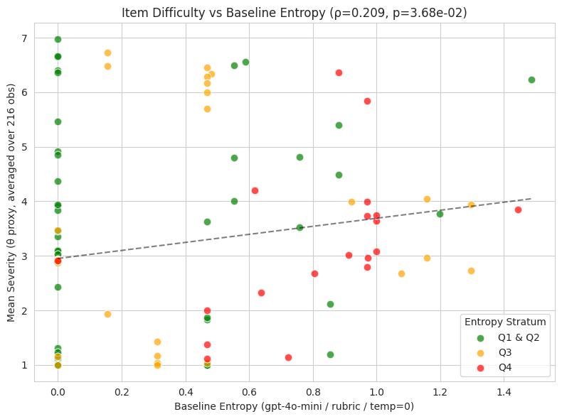

Saved output 4 · stream

```
Saved to ./02.MentalHealth/outputs
```

Original cell 18 · markdown

### Krippendorff's Alpha (Ordinal)

**Note on aggregation:** Severity ratings were aggregated to modal values per item × evaluator prior to computing Krippendorff's α, preserving ordinal scale properties.

**Original Markdown text**

```
### Krippendorff's Alpha (Ordinal)

**Note on aggregation:** Severity ratings were aggregated to modal values per item × evaluator prior to computing Krippendorff's α, preserving ordinal scale properties.
```

Original cell 19 · code · saved execution 14

```
print("=" * 70)
print("KRIPPENDORFF'S ALPHA — ordinal (severity_7)")
print("=" * 70)

# Aggregate over seeds AND temps: mode severity per item × evaluator
agg_sev = results.groupby(["item_id", "evaluator"])["severity_7"].agg(lambda x: x.mode().iloc[0] if len(x.mode()) > 0 else x.iloc[0]).reset_index()
pivot_sev = agg_sev.pivot(index="item_id", columns="evaluator", values="severity_7")
alpha_overall = krippendorff_alpha_ordinal(pivot_sev)
print(f"\nOverall Krippendorff's alpha (ordinal): {alpha_overall:.4f}")

# By prompt type
print("\nKrippendorff's alpha by prompt type:")
for pt in sorted(results["prompt_type"].unique()):
    sub = results[results["prompt_type"] == pt]
    agg_sub = sub.groupby(["item_id", "evaluator"])["severity_7"].agg(lambda x: x.mode().iloc[0] if len(x.mode()) > 0 else x.iloc[0]).reset_index()
    pivot_sub = agg_sub.pivot(index="item_id", columns="evaluator", values="severity_7")
    alpha_pt = krippendorff_alpha_ordinal(pivot_sub)
    print(f"  {pt:15s}  alpha = {alpha_pt:.4f}")
```

Saved output 1 · stream

```
======================================================================
KRIPPENDORFF'S ALPHA — ordinal (severity_7)
======================================================================

Overall Krippendorff's alpha (ordinal): 0.8561

Krippendorff's alpha by prompt type:
  cot              alpha = 0.8463
  minimal          alpha = 0.7443
  rubric           alpha = 0.8206
```

Original cell 20 · code · saved execution 15

```
print("=" * 70)
print("PAIRWISE EVALUATOR AGREEMENT")
print("=" * 70)

# Kappa matrix computed on the numeric 7-level severity score so that the
# quadratic weighting reflects the clinical severity gradient (NORMAL → SUICIDAL),
# not the alphabetical ordering of the raw category names.
print("\n--- Weighted Kappa (quadratic, mode-aggregated severity_7) ---")
kappa_mat = pairwise_agreement(
    results, item_col="item_id", rater_col="evaluator",
    label_col="severity_7", agg_func="mode", metric="kappa",
)
print(kappa_mat.to_string())

# Mean pairwise kappa across the C(4,2) = 6 evaluator pairs
import numpy as _np
_k = kappa_mat.values
_off = _k[_np.triu_indices_from(_k, k=1)]
print(f"\nMean pairwise kappa_w (severity_7, across 6 pairs): {_off.mean():.4f}")

# Agreement rate matrix (stays on raw label for exact-match counting)
print("\n--- Pairwise Agreement Rate (mode label) ---")
agr_mat = pairwise_agreement(
    results, item_col="item_id", rater_col="evaluator",
    label_col="label", agg_func="mode", metric="accuracy",
)
print(agr_mat.to_string())
```

Saved output 1 · stream

```
======================================================================
PAIRWISE EVALUATOR AGREEMENT
======================================================================

--- Weighted Kappa (quadratic, mode-aggregated severity_7) ---
                  gemini-2.5-flash  gpt-4o-mini  llama-70b  mistral-small
gemini-2.5-flash             1.000       0.8340     0.8610         0.8020
gpt-4o-mini                  0.834       1.0000     0.8893         0.8724
llama-70b                    0.861       0.8893     1.0000         0.8663
mistral-small                0.802       0.8724     0.8663         1.0000

Mean pairwise kappa_w (severity_7, across 6 pairs): 0.8542

--- Pairwise Agreement Rate (mode label) ---
                  gemini-2.5-flash  gpt-4o-mini  llama-70b  mistral-small
gemini-2.5-flash              1.00         0.83       0.82           0.77
gpt-4o-mini                   0.83         1.00       0.84           0.81
llama-70b                     0.82         0.84       1.00           0.80
mistral-small                 0.77         0.81       0.80           1.00
```

Original cell 26 · code · saved execution 20

```
print("=" * 70)
print("PROBABILITY CALIBRATION — ECE")
print("=" * 70)
# NOTE: ECE computed on aggregated (per-item x per-evaluator) data to avoid
# pseudo-replication from repeated prompt/temperature/seed combinations.

prob_cols = [
    "prob_normal", "prob_depression", "prob_anxiety", "prob_suicidal",
    "prob_stress", "prob_bipolar", "prob_personality_disorder",
]
labels_list = [
    "NORMAL", "DEPRESSION", "ANXIETY", "SUICIDAL",
    "STRESS", "BIPOLAR", "PERSONALITY_DISORDER",
]

# Aggregate: mode label + mean probability per item x evaluator
agg_for_ece = results.groupby(['item_id', 'evaluator']).agg(
    label=('label', lambda x: x.mode().iloc[0]),
    **{pc: (pc, 'mean') for pc in prob_cols}
).reset_index()

# Overall ECE (on aggregated data)
cal_overall = calibration_metrics(agg_for_ece, prob_cols, "label", labels_list, n_bins=10)
print(f"\nOverall ECE: {cal_overall['ece']:.4f}")

# Per evaluator (on aggregated data)
print("\n--- ECE by evaluator ---")
for ev in sorted(agg_for_ece["evaluator"].unique()):
    sub = agg_for_ece[agg_for_ece["evaluator"] == ev]
    cal_ev = calibration_metrics(sub, prob_cols, "label", labels_list, n_bins=10)
    print(f"  {ev:25s}  ECE = {cal_ev['ece']:.4f}")
```

Saved output 1 · stream

```
======================================================================
PROBABILITY CALIBRATION — ECE
======================================================================

Overall ECE: 0.0726

--- ECE by evaluator ---
  gemini-2.5-flash           ECE = 0.0722
  gpt-4o-mini                ECE = 0.0596
  llama-70b                  ECE = 0.0886
  mistral-small              ECE = 0.0879
```